# Multiple and Linear Regressions (extended)

Florencia Zúñiga

7/9/2019

# Multiple and Linear Regressions

#Table of contents

1. LOADING DATA

- 1.1. Biomarkers

2. PREPARING THE DATA

- 2.1 Creating the necessary tables (Copynumber with biomarkers/all genes and Cell lines with drug sensitivity)

3. SIMPLE LINEAR REGRESSION WITH ALL GENES: Drug sensitivity with doubling time

- 3.1. Plots and visualization: Predicting how fit linear regression will be as a model to describe our data
- 3.2. Linear Regression
- 3.3. Checking the normalization of residuals
- 3.4. Visualization: Plots that describe the linear regression

4. SIMPLE LINEAR REGRESSION WITH 100 BIOMARKERS: Drug sensitivity with copynumber

- 4.1. Plots and visualization: Predicting how fit linear regression will be as a model to describe our data
- 4.2. Linear Regression
- 4.3. Checking the normalization of residuals
- 4.4. Visualization: Plots that describe the linear regression

5.SIMPLE LINEAR REGRESSION WITH ALL GENES: Drug sensitivity with copynumber

- 5.1. Plots and visualization: Predicting how fit linear regression will be as a model to describe our data
- 5.2. Linear Regression
- 5.3. Checking the normalization of residuals
- 5.4. Visualization: Plots that describe the linear regression

6.MULTIPLE REGRESSION WITH ALL GENES: Drug sensitivity with doubling time and copynumber

- 6.1. Plots and visualization: Predicting how fit linear regression will be as a model to describe our data
- 6.2. Linear Regression
- 6.3. Checking the normalization of residuals
- 6.4. Visualization: Plots that describe the linear regression

7.General Conclusions

8.Using PCA to determine independent variables

- 8.1. PCA
- 8.2. A little correlation exploration
- 8.3. Linear Regression

9.REMOVING THE OUTLIERS: Simple linear regression of all genes for drug sensitivity using doubling time

- 9.1. Boxplot: removing the outliers
- 9.2. Linear Regression removing the outliers
- 9.3. Checking the normalization of residuals
- 9.4. Visualization: Plots that describe the linear regression
- 9.5. General Conclusions

10.Comparing the results for the linear regression of drug sensitivity vs copynumber using only the biomarkers wvs using all genes

11. Linear Regression with specific genes: Drug Sensitivity vs Copynumber

- 11.1. Linear Regression with top 3 biomarkers
- 11.2. Linear Regression with 3 non-biomarker genes
- 11.3. Linear Regression with genes with the highest and lowest mean values for copynumber

12. Table with summary

# **PART 1**

# 1. LOADING DATA (#anchor1)

Needed libraries:

```r
library(readr)
library(rstudioapi)
```

Reading the data

```r
Untreated <- readRDS(paste0(wd,"/data/NCI_TPW_gep_untreated.rds"))
Treated <- readRDS(paste0(wd,"/data/NCI_TPW_gep_treated.rds"))

Metadata = read.table(paste0(wd,"/data/NCI_TPW_metadata.tsv"),
                      header = TRUE, sep ="\t", stringsAsFactors = TRUE)

Sensitivity <- readRDS(paste0(wd,"/data/NegLogGI50.rds"))


Basal <- readRDS(paste0(wd,"/data/CCLE_basalexpression.rds"))
Copynumber <- readRDS(paste0(wd,"/data/CCLE_copynumber.rds"))
Mutations <- readRDS(paste0(wd,"/data/CCLE_mutations.rds"))

Cellline_annotation = read.table(paste0(wd,"/data/cellline_annotation.tsv"),
                                 header = TRUE, sep ="\t", stringsAsFactors = TRUE)
Drug_annotation = read.table(paste0(wd,"/data/drug_annotation.tsv"),
                             header = TRUE, sep ="\t", stringsAsFactors = TRUE)
```

Transforming the data

```r
Treated <- as.data.frame(Treated)
Untreated <- as.data.frame(Untreated)
Sensitivity<- as.data.frame(Sensitivity)
```

Data normalization

```r
Untreated_norm <- apply(Untreated, 2, function(x){
  (x - mean(x)) / sd(x)
 })


Treated_norm <- apply(Treated, 2, function(x){
  (x - mean(x)) / sd(x)
 })


FC <- Treated - Untreated
FC_norm <- apply(FC, 2, function(x){
  (x - mean(x)) / sd(x)
 })
```

## 1.1 Biomarkers (#anchor2)

### (1) Creating Vorinostat

```r
#Untreated matrix
UntreatedVorinostatcolumns <- grep(pattern = "vorinostat",colnames(Untreated))

#Same with treated matrix
TreatedVorinostatcolumns <- grep(pattern = "vorinostat",colnames(Treated))

#Define Vorinostat-data:
UntreatedVorinostat <- Untreated[,UntreatedVorinostatcolumns]
TreatedVorinostat <- Treated[,TreatedVorinostatcolumns]

#fold change matrix
FC <- TreatedVorinostat - UntreatedVorinostat

#Sensitivity
vorinostat_Sensitivity_alleZeilen= grep ('vorinostat', rownames(Sensitivity))
vorinostat_Sensitivity_data= Sensitivity[vorinostat_Sensitivity_alleZeilen,]
```

### (2) Creating FC Data - Finding the Biomarkers

```r
FC <- TreatedVorinostat - UntreatedVorinostat

#We work with mean of the rows because we only want to compare the genes
FC_meanrow= rowMeans(FC)

## Sorting the data
#We work with absolute value to find the highest values,
#because we want to have the most up and down regulated genes.
FC_abs= abs(FC_meanrow)

#We sort the values to get the 100 largest values
sortedFC_abs <- sort(FC_abs, decreasing = TRUE)
sortedFC_abs <- as.matrix(sortedFC_abs)

#We select the first n for biomarkers
biomarkers_FC30 = sortedFC_abs[1:30,]
biomarkers_FC30 <- as.matrix(biomarkers_FC30)

biomarkers_FC100 = sortedFC_abs[1:100,]
biomarkers_FC100 <- as.matrix(biomarkers_FC100)

## Creating a matrix with FC values, that are both positive and negative
FC_both= cbind(FC_meanrow,FC_abs)
FC_both=as.data.frame(FC_both)

#Ordering this matrix
FC_both_sorted <- FC_both[order(FC_both$FC_abs, decreasing = TRUE),]

#FC values of biomarkers: We select the first 100 of the sorted matrix.
biomarkers_FC_values30 = FC_both_sorted[1:30,]

biomarkers_FC_values100 = FC_both_sorted[1:100,]

#Removing the absolute values
biomarkers_FC_values30 <- subset( biomarkers_FC_values30, select = -FC_abs)
biomarkers_FC_values30 = as.matrix(biomarkers_FC_values30)

biomarkers_FC_values100 <- subset( biomarkers_FC_values100, select = -FC_abs)
biomarkers_FC_values100 = as.matrix(biomarkers_FC_values100)
```

# 2. PREPARING THE DATA (#anchor3)

## 2.1 Creating the necessary tables (Copynumber with biomarkers/all genes and Cell lines with drug sensitivity) (#anchor4)

### (1) Table 1: Selection of 100 Biomarkers in copynumber

```r
BM_copynumber = Copynumber[ which(row.names(Copynumber)
                                  %in% rownames(biomarkers_FC_values100)), ]

BM_Copynumber_meancol= colMeans(BM_copynumber)

CN = as.data.frame(BM_Copynumber_meancol)
```

### (2) Table 2: All genes in copynumber

```r
CN_meancol= colMeans(Copynumber)

CN_all = as.data.frame(CN_meancol)
```

### (3) Table 3: Selection of Doubling time from cellline_annotation

```r
#Loading package
library(dplyr)
#Selecting the desired columns
Doubling_Time <- Cellline_annotation %>%
  select(Cell_Line_Name, Doubling_Time)

#Changig the name of the "name" column to the names of the cell lines

row.names(Doubling_Time) <- Doubling_Time$Cell_Line_Name
Doubling_Time[1] <- NULL
```

### (4) Table 4: Selection of vorinostat row from Sensitivity

```r
drug_sensitivity <- Sensitivity[-c(1:14),]

drug_sensitivity = t(drug_sensitivity)
```

# 3. SIMPLE LINEAR REGRESSION WITH ALL GENES: Drug sensitivity with doubling time (#anchor5)

Can we predict drug sensitivity using doubling time? How much of the variance of the data can be explained using the doubling time?

### Data frames

```r
DT = as.data.frame(Doubling_Time)

DS = as.data.frame(drug_sensitivity)
```

### Table with drug sensitivity and doubling time per cell line

```r
lm_tab = transform(merge(DT,DS,by=0,all=TRUE), row.names=Row.names, Row.names=NULL)
```

## 3.1 Plots and visualization: Predicting how fit linear regression will be as a model to describe our data

Ploting the data: can a linear relationship be observed? Should we expect a high value for R-squared?

Here we aim to Visualize the relationship between doubling time and drug sensitivity

#### (1) Scatter Plot

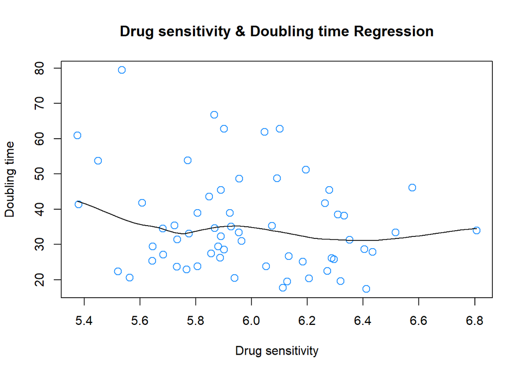

```r
scatter.smooth(lm_tab$vorinostat,
               lm_tab$Doubling_Time,
               col = "dodgerblue1",
               main = "Drug sensitivity & Doubling time Regression",
               xlab = "Drug sensitivity",
               ylab = "Doubling time",
               cex = 1.3,
               pch = 1)
```

At first look, the points in the plot are so scattered, that a linear relationship seems unlikely. The second problem that one can observe in this graphic, is that the line describing the behaviour is not straight.

#### (2) Box plot

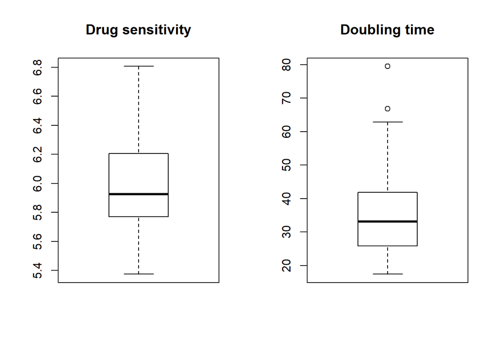

```r
par(mfrow=c(1, 2))
boxplot(lm_tab$vorinostat,
        main="Drug sensitivity")

boxplot(lm_tab$Doubling_Time,
        main="Doubling time")
```

A boxplot can help us visualize the amount of outliers in our data. This is relevant as too many (extreme) outliers can have great impact on the results of our analysis and can change the outcome completely. They can easily affect the slope. Two outliers can be observed. Considering that the table lm_tab describes the behaviour of 61 cell lines, these two outliers correspond approximately only to a 3.28% of our data. This is of course not much. But how much can that 3.28% affect our end results? What impact do the outliers have on the fit of the linear model? Would we have better results if we just removed the outliers? These are all questions we explore in the final part of the exploration related to linear regression, as these are interesting questions for an analysis of statistical nature such as this one.

#### (3) Density: Should we expect normality for drug sensitivity?

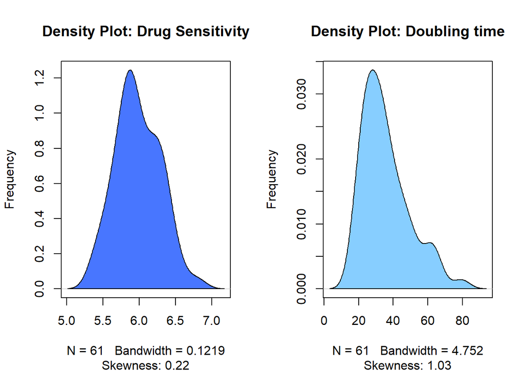

```r
library(e1071)

par(mfrow=c(1, 2))

plot(density(lm_tab$vorinostat),
     main="Density Plot: Drug Sensitivity",
     ylab="Frequency",
     sub=paste("Skewness:", round(e1071::skewness(lm_tab$vorinostat), 2))
     )

polygon(density(lm_tab$vorinostat), col="royalblue1")

plot(density(lm_tab$Doubling_Time),
     main="Density Plot: Doubling time",
     ylab="Frequency",
     sub=paste("Skewness:", round(e1071::skewness(lm_tab$Doubling_Time), 2))
    )

polygon(density(lm_tab$Doubling_Time), col="skyblue1")
```

Skewness of the plot on the left: 0.22 -> Plot is slightly skewed to the right

Skewness of the plot on the right: 1.03 -> Plot is skewed to the right.

The shape of a density plot and its skewness, give us an idea of how well normalized our data is. Taking this into consideration, it is worth noting that the plot for doubling time is considerably skewed to the right. This tells us our data is not very well normalized.

#### (4) Correlation: what is the level level of linear dependence between the two variables?

```r
cor(lm_tab$vorinostat, lm_tab$Doubling_Time)
```

```
## [1] -0.2057795
```

A good value for correlation lies close to 1 or -1, whilst the value 0 is undesirable. Values closer to 0 indicate that there is a weak relationship. The results shows us that there is a weak correlation with a negative slope.

These analysis help us predcit whether a linear regression is or not the best model to describe our data. Taking into consideration all results so far for this part, it is not unreasonable to predict that a linear regression will probably not be the best model to describe the relationships in our data.

## 3.2 Linear Regression

This is the function for a linear regression:

linear_regression = lm(predicted ~ predictor, data = dat)

### Linear Regression

```r
reg1 <- lm(vorinostat ~ Doubling_Time, data = lm_tab)
```

### Details about the linear regression: what we need draw some conclusions

```r
summary(reg1)
```

```
##
## Call:
## lm(formula = vorinostat ~ Doubling_Time, data = lm_tab)
##
## Residuals:
##      Min       1Q   Median       3Q      Max
## -0.57361 -0.22994 -0.03867  0.24528  0.81819
##
## Coefficients:
##                Estimate Std. Error t value Pr(>|t|)
## (Intercept)    6.144923   0.109253  56.245   <2e-16 ***
## Doubling_Time -0.004621   0.002861  -1.615    0.112
## ---
## Signif. codes:  0 '***' 0.001 '**' 0.01 '*' 0.05 '.' 0.1 ' ' 1
##
## Residual standard error: 0.3042 on 59 degrees of freedom
## Multiple R-squared:  0.04235,    Adjusted R-squared:  0.02611
## F-statistic: 2.609 on 1 and 59 DF,  p-value: 0.1116
```

Multiple R-squared: 0.04235 This indicates that only 4,235% percent of the variation in the data (drug sensitivity) can be explained by the relationship between drug sensitivity and doubling time. In other words, there is a 4.235% variance reduction when we take the doubling time into account.

p-value: 0.1116 As the p-value for reg1 is significantly larger than 0.05 and R-squared tells us the doubling time only explains 4.235% of the variation in the data, it is safe to assume that there is no linear relationship between drug sensitivity and doubling time, a.k.a doubling time cannot predict drug sensitivity.

More information about the fit (linear ecuation: y = y-intercept + slope * x) can be found by checking the confidence interval.

```r
confint(reg1)
```

```
##                     2.5 %      97.5 %
## (Intercept)    5.92630793 6.363537831
## Doubling_Time -0.01034593 0.001103791
```

We can also visualize the results of the confidence interval

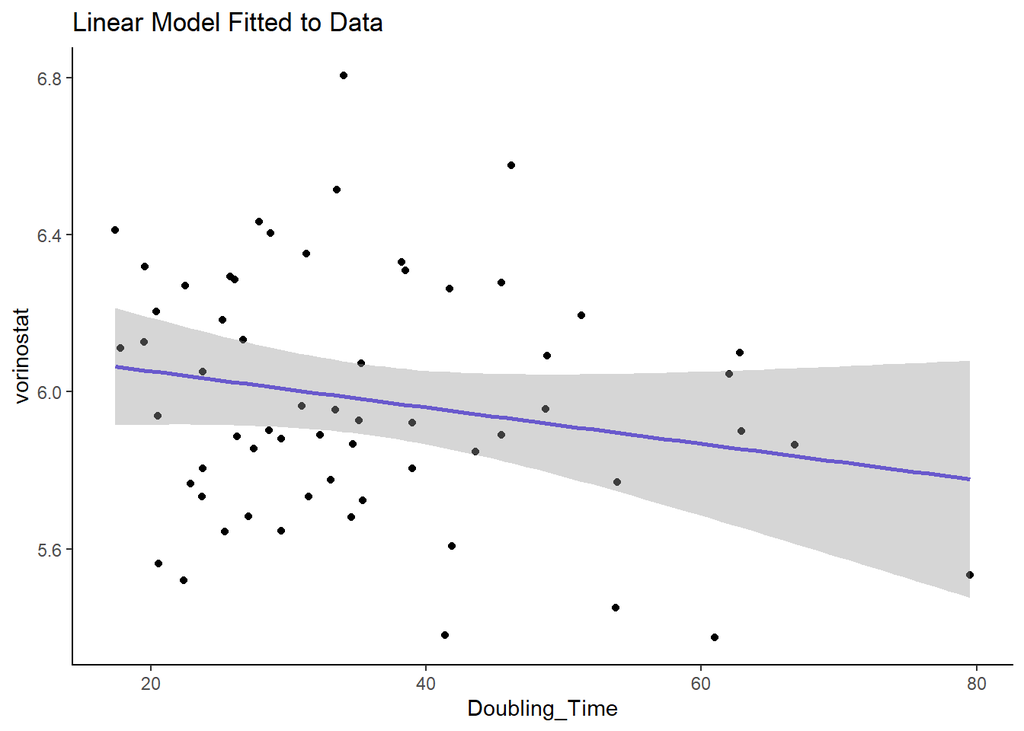

```r
library(ggplot2)

ggplot(data = lm_tab, aes(x = Doubling_Time, y = vorinostat)) +
  geom_point() +
  stat_smooth(method = "lm", col = "slateblue3", level = 0.975) +
  theme(panel.background = element_rect(fill = "white"),
        axis.line.x=element_line(),
        axis.line.y=element_line()) +
  ggtitle("Linear Model Fitted to Data")
```

The grey area represents the 97.5% confidence interval. This tells us the probability that the true value we want to find is within this grey area with a 97.5% chance. As the doubling time increases, the uncertainty gets higher. Eventhough many points are inside the grey area, there are many more that are scattered across the graph.

## 3.3 Checking the normalization of residuals

Here we explore two ways to visualize the normalization of residuals.

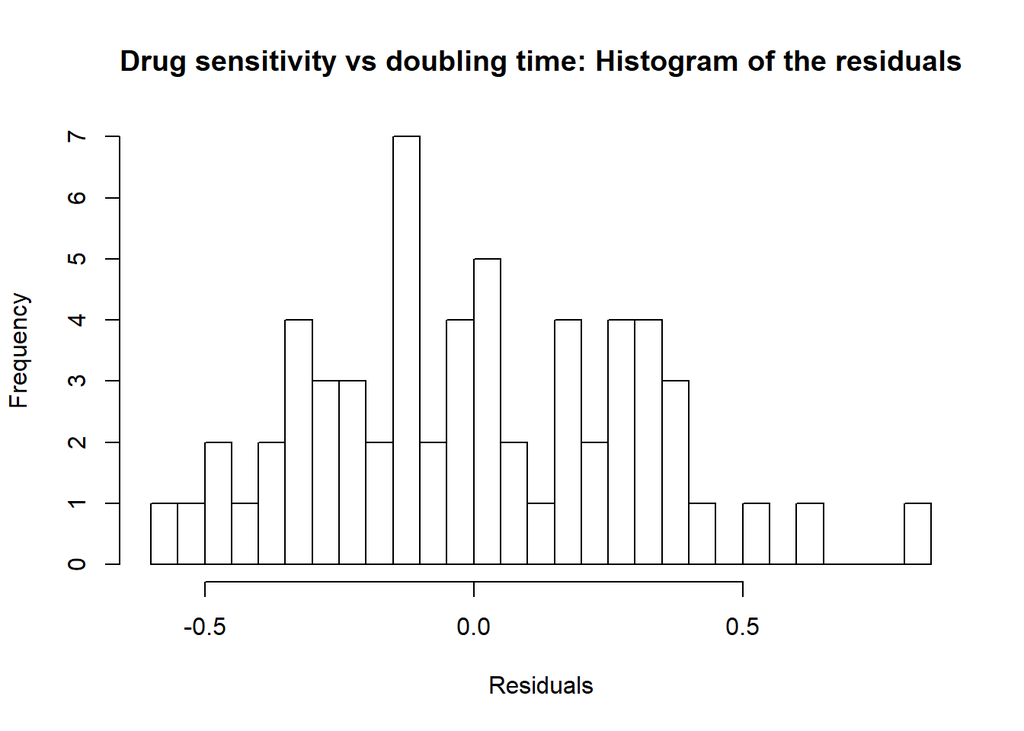

```r
hist(reg1$residuals,
     breaks = 20,
     xlab = "Residuals",
     main = "Drug sensitivity vs doubling time: Histogram of the residuals")
```

The data does NOT look normally distributed: As the residuals are not normally distributed, then the hypothesis that they are a random dataset, takes the value NO. This means that the linear regression model does not explain all trends in the dataset.

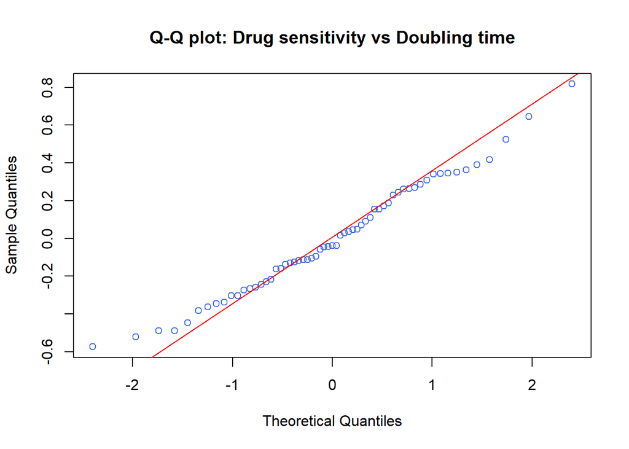

```r
qqnorm(reg1$residuals, col = "royalblue2", main = "Q-Q plot: Drug sensitivity vs Doubling time")
qqline(reg1$residuals, col = "red")
```

Here we expect to be able to draw a straight line that is fitting for most points. Although, this graphic seems promising, too many points would not be properly fit. Around both ends of the lines, there are many points that are not following it properly.

## 3.4 Visualization: Plots that describe the linear regression

### Residual diagnostics: are the various assumptions that underpin linear regression reasonable for our data?

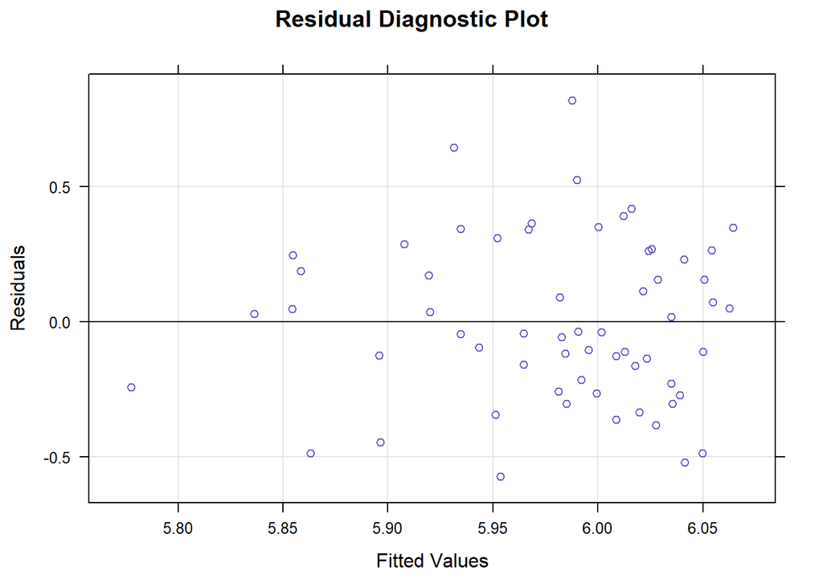

```r
library(lattice)

xyplot(resid(reg1) ~ fitted(reg1),
       xlab = "Fitted Values",
       ylab = "Residuals",
       main = "Residual Diagnostic Plot",
       col = "slateblue3",
       panel = function(x, y, ...)
       {
         panel.grid(h = -1, v = -1)
         panel.abline(h = 0)
         panel.xyplot(x, y, ...)
       }
      )
```

#### Visualization of regression

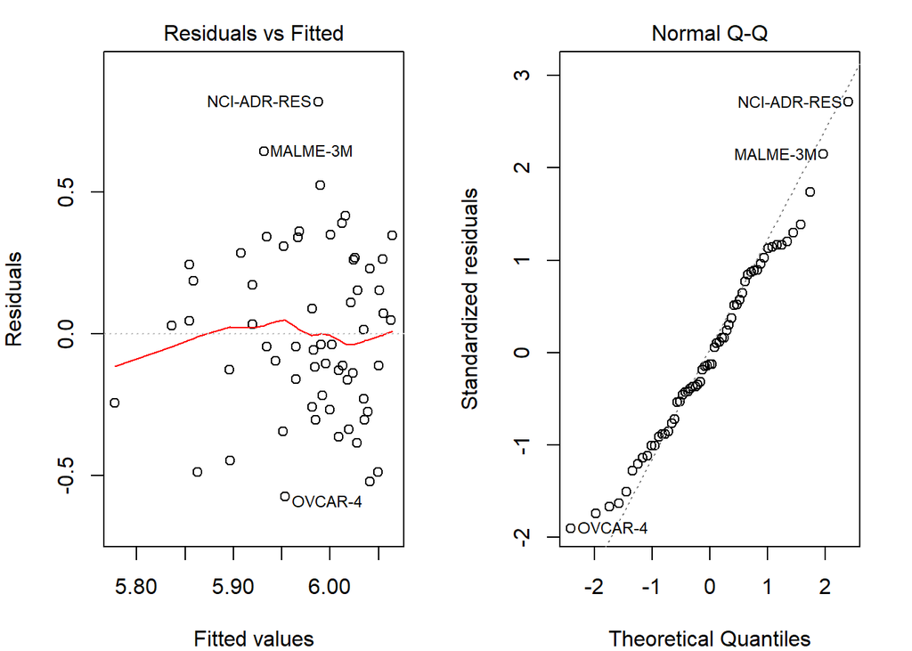

```r
par(mar = c(4, 4, 2, 2), mfrow = c(1, 2))
plot(reg1, which = c(1, 2))
```

In these graphs, we can observe the behaviour of 3 cell lines under a linear regression model. The red line on the graph on the left lets us se that a linear relationship is unlikely.

#### Comparing prediction and real values for drug sensitivity

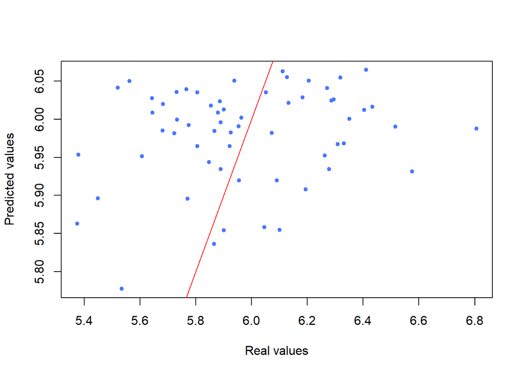

```r
plot(lm_tab$vorinostat,
     reg1$fitted.values,
     pch = 20,
     col = "royalblue1",
     xlab = "Real values",
     ylab = "Predicted values")
abline(0, 1, col = "red")
```

The data points are quite scattered.

# 4. SIMPLE LINEAR REGRESSION WITH 100 BIOMARKERS: Drug sensitivity with copynumber

Can we predict drug sensitivity using the copynumber data? How much of the variance of the data can be explained using the copynumber data?

### Data frames

```r
CN = as.data.frame(BM_Copynumber_meancol)

DS = as.data.frame(drug_sensitivity)
```

```r
lm_tab2 = transform(merge(CN,DS,by=0,all=TRUE), row.names=Row.names, Row.names=NULL)
lm_tab2 <- na.omit(lm_tab2)
```

Because not all values included in copynumber are in drug sensitivity, the NAs are omitted.

## 4.1 Plots and visualization: Predicting how fit linear regression will be as a model to describe our data

Ploting the data: can a linear relationship be observed? Should we have expected a high value for R-squared?

#### (1) Scatter Plot

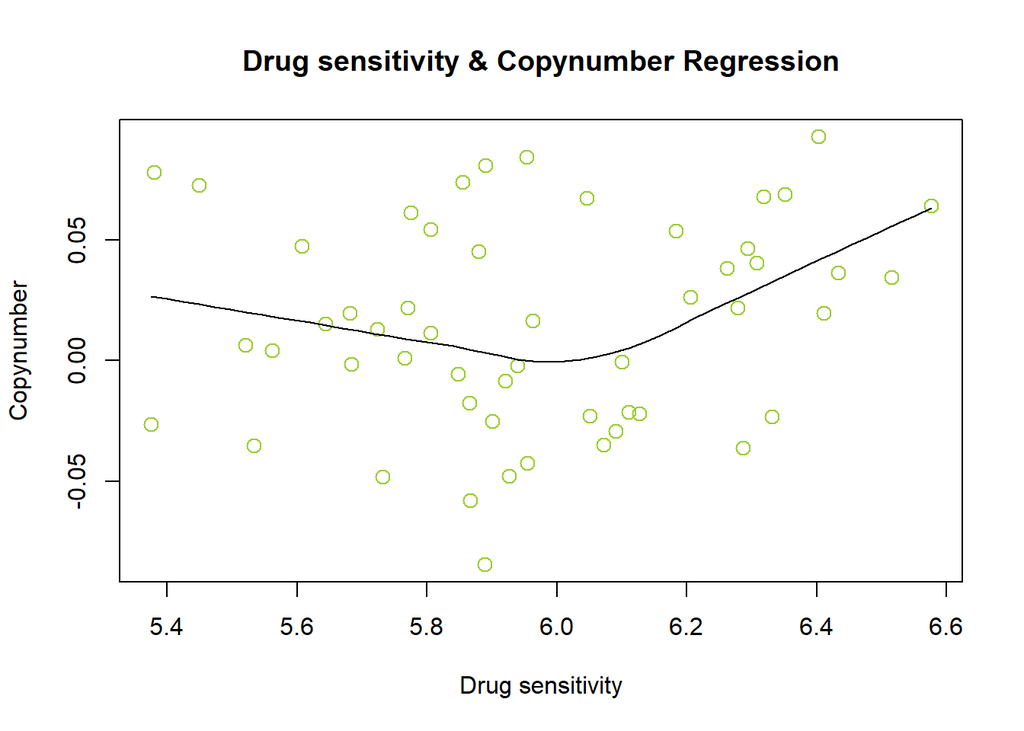

```r
scatter.smooth(lm_tab2$vorinostat,
              lm_tab2$BM_Copynumber_meancol,
              col = "yellowgreen",
              main = "Drug sensitivity & Copynumber Regression",
              xlab = "Drug sensitivity",
              ylab = "Copynumber",
              cex = 1.3,
              pch = 1)
```

At first look, the points in the plot are so scattered, that a linear relationship seems unlikely. The second problem that one can observe in this graphic, is that the line describing the behaviour is not straight.

#### (2) Box plot

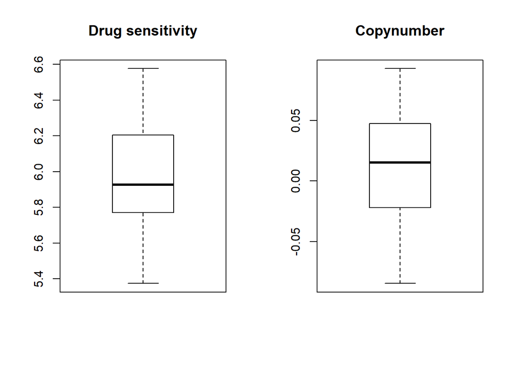

```r
par(mfrow=c(1, 2))
boxplot(lm_tab2$vorinostat,
        main="Drug sensitivity")
boxplot(lm_tab2$BM_Copynumber_meancol,
        main="Copynumber")
```

No outliers can be observed. This is good, because there is no extreme data that can affect the slope for the linear regression.

#### (3) Density: Should we expect normality for drug sensitivity?

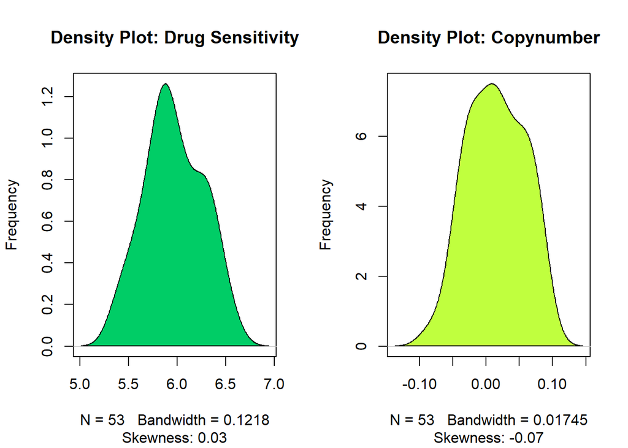

```r
library(lattice)

par(mfrow=c(1, 2))

plot(density(lm_tab2$vorinostat),
     main="Density Plot: Drug Sensitivity",
     ylab="Frequency",
     sub=paste("Skewness:", round(e1071::skewness(lm_tab2$vorinostat), 2))
    )

polygon(density(lm_tab2$vorinostat), col="springgreen3")

plot(density(lm_tab2$BM_Copynumber_meancol),
     main="Density Plot: Copynumber",
     ylab="Frequency",
     sub=paste("Skewness:", round(e1071::skewness(lm_tab2$BM_Copynumber_meancol), 2))
    )

polygon(density(lm_tab2$BM_Copynumber_meancol), col="olivedrab1")
```

Skewness of the plot on the left: 0.03 -> Plot is very slightly skewed to the right. Skewness of the plot on the right: -0.07 -> Plot is very slightly skewed to the left.

The data seems to be well normalized in terms of skewness, but the shape of the plots does not match very well that of a classic normalized density plot.

#### (4) Correlation: what is the level level of linear dependence between the two variables?

```r
cor(lm_tab2$vorinostat, lm_tab2$BM_Copynumber_meancol)
```

```
## [1] 0.1587939
```

The value here is extremely low, so a linear relationship is not a very good option to describe the data.

Eventhough both the box plots (2) and the density plots (3) results could have been good indicators for a linear relationship, the lack of a fitting straight line on the scatter plotc(1) and the low value in the result of the correlation (4) indicate the opposite.

Taking into consideration all results so far for this part, it is not unreasonable to predict that a linear regression will probably not be the best model to describe the relationships in our data.

## 4.2 Linear Regression

### Linear Regression

```r
reg2 <- lm(vorinostat ~ BM_Copynumber_meancol, data = lm_tab2)
```

### Details about the linear regression: what we need draw some conclusions

```r
summary(reg2)
```

```
##
## Call:
## lm(formula = vorinostat ~ BM_Copynumber_meancol, data = lm_tab2)
##
## Residuals:
##      Min       1Q   Median       3Q      Max
## -0.65640 -0.20402 -0.00818  0.22604  0.55500
##
## Coefficients:
##                       Estimate Std. Error t value Pr(>|t|)
## (Intercept)            5.94966    0.04351 136.757   <2e-16 ***
## BM_Copynumber_meancol  1.10884    0.96540   1.149    0.256
## ---
## Signif. codes:  0 '***' 0.001 '**' 0.01 '*' 0.05 '.' 0.1 ' ' 1
##
## Residual standard error: 0.2986 on 51 degrees of freedom
## Multiple R-squared:  0.02522,    Adjusted R-squared:  0.006102
## F-statistic: 1.319 on 1 and 51 DF,  p-value: 0.2561
```

#### More information about the fit (linear ecuation: y = y-intercept + slope * x) :

```r
confint(reg2)
```

```
##                            2.5 %   97.5 %
## (Intercept)            5.8623184 6.036999
## BM_Copynumber_meancol -0.8292712 3.046958
```

We can also visualize the results of the confidence interval

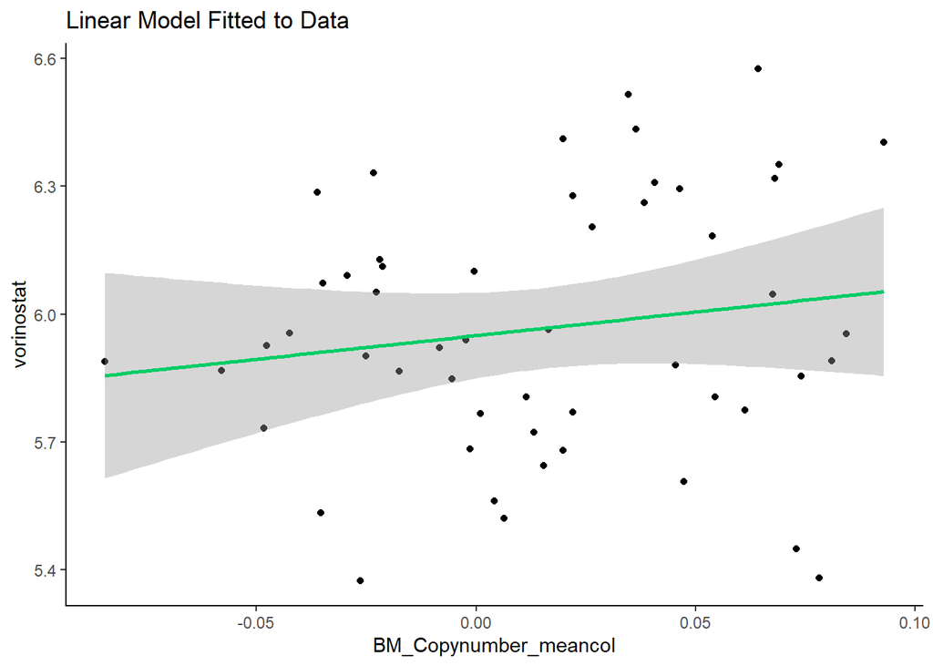

```r
library(ggplot2)

ggplot(data = lm_tab2, aes(x = BM_Copynumber_meancol, y = vorinostat)) +
  geom_point() +
  stat_smooth(method = "lm", col = "springgreen3", level = 0.975) +
  theme(panel.background = element_rect(fill = "white"),
        axis.line.x=element_line(),
        axis.line.y=element_line()) +
  ggtitle("Linear Model Fitted to Data")
```

Eventhough many points are inside the grey area, there are many more that are scattered across the graph. The confidence interval is very big and the data dispersed. There is no correlation between the variables.

## 4.3 Checking the normalization of residuals

Here we explore two ways to visualize the normalization of residuals.

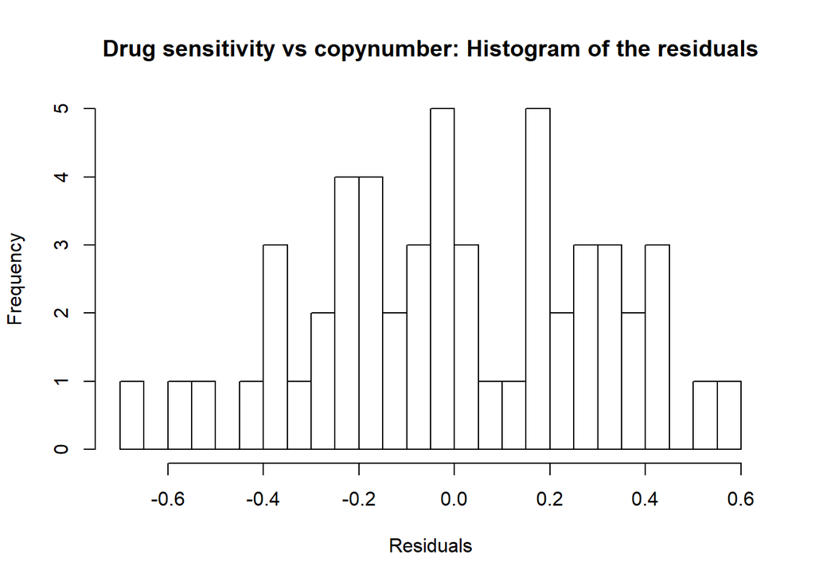

```r
hist(reg2$residuals,
     breaks = 20,
     xlab = "Residuals",
     main = "Drug sensitivity vs copynumber: Histogram of the residuals")
```

The graph lets us see that the residuals are not normally distributed.

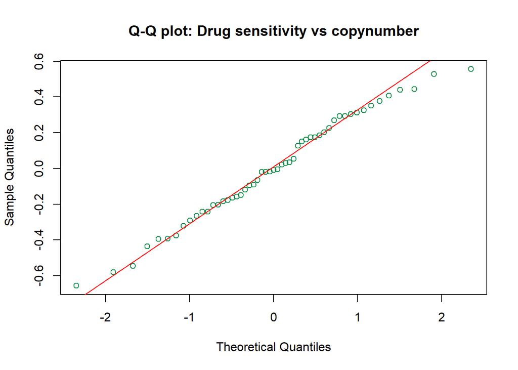

```r
qqnorm(reg2$residuals, col = "springgreen4", main = "Q-Q plot: Drug sensitivity vs copynumber")
qqline(reg2$residuals, col = "red")
```

Most points of the data seem to meet the red line. However, it is important to take note of the points that are potitioned after the 2nd Quantile, as they are the ones that distance themselves the most from the red line.

## 4.4 Visualization: Plots that describe the linear regression

### Residual diagnostics: are the various assumptions that underpin linear regression reasonable for our data?

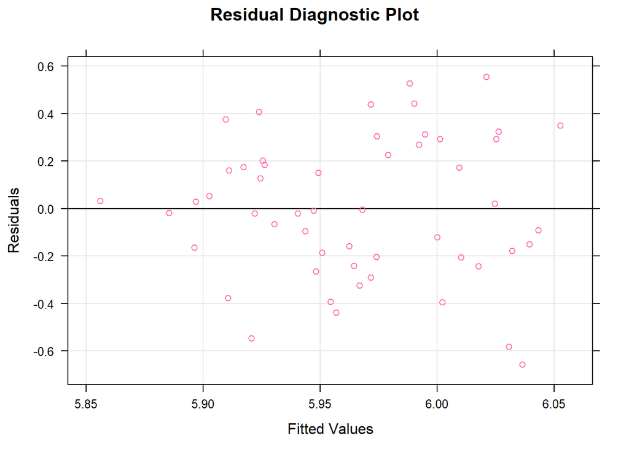

```r
library(lattice)

xyplot(resid(reg2) ~ fitted(reg2),
       xlab = "Fitted Values",
       ylab = "Residuals",
       main = "Residual Diagnostic Plot",
       col = "hotpink1",
       panel = function(x, y, ...)
       {
         panel.grid(h = -1, v = -1)
         panel.abline(h = 0)
         panel.xyplot(x, y, ...)
       }
      )
```

#### Visualization of regression

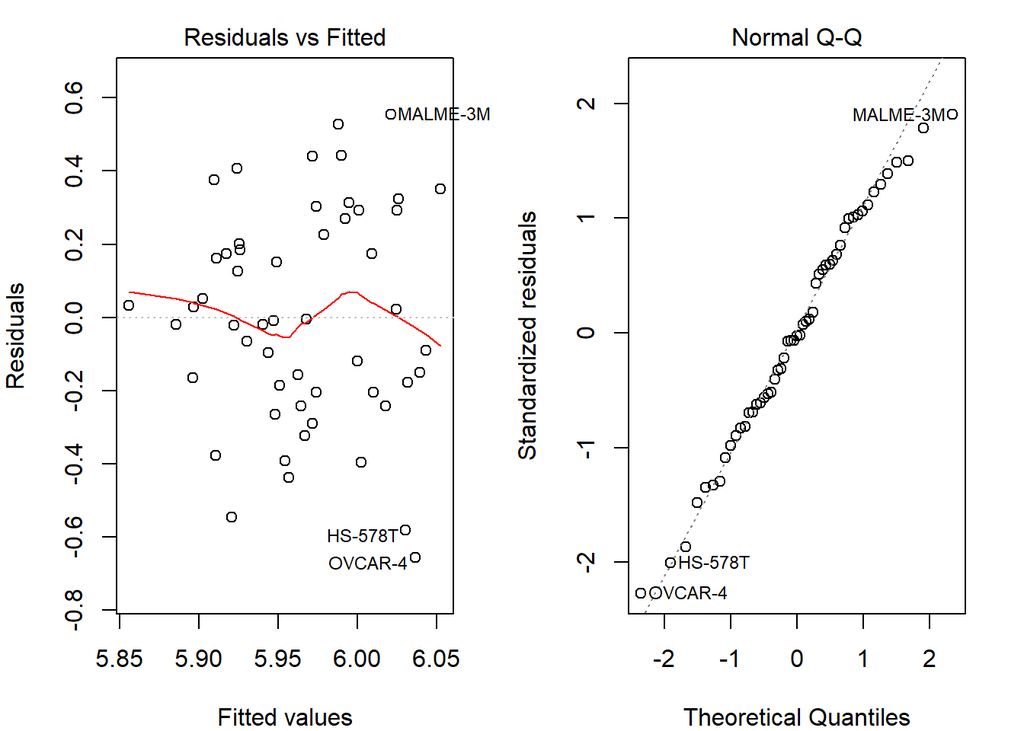

```r
par(mar = c(4, 4, 2, 2), mfrow = c(1, 2))
plot(reg2, which = c(1, 2))
```

The red line of the Residual vs Fitted graph is a good tool that lets us visualize just how disperse our data is and that a linear model is not a good fit to describe the data.

#### Comparing prediction and real values for drug sensitivity

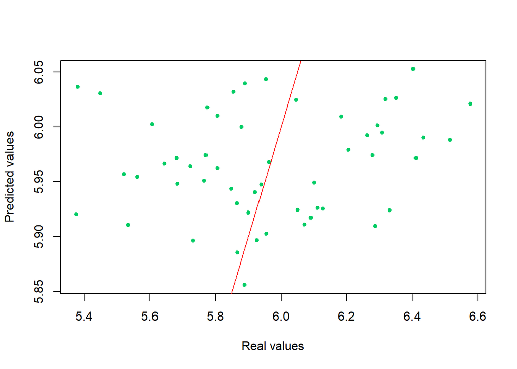

```r
plot(lm_tab2$vorinostat,
     reg2$fitted.values,
     pch = 20, col = "springgreen3",
     xlab = "Real values",
     ylab = "Predicted values")
abline(0, 1, col = "red")
```

# 5. SIMPLE LINEAR REGRESSION WITH ALL GENES: Drug sensitivity with copynumber

Can we predict drug sensitivity using the copynumber data for all genes? How much of the variance of the data can be explained using the copynumber data?

Which differences will we see in our data when we consider the copynumber of all genes, instead of just the biomarkers?

### Data frames

```r
CN_all = as.data.frame(CN_meancol)

DS = as.data.frame(drug_sensitivity)
```

```r
lm_tab_all2 = transform(merge(CN_all,DS,by=0,all=TRUE), row.names=Row.names, Row.names=NULL)
lm_tab_all2 <- na.omit(lm_tab_all2)
```

## 5.1 Plots and visualization: Predicting how fit linear regression will be as a model to describe our data

### Ploting the data: can a linear relationship be observed? Should we have expected a high value for R-squared?

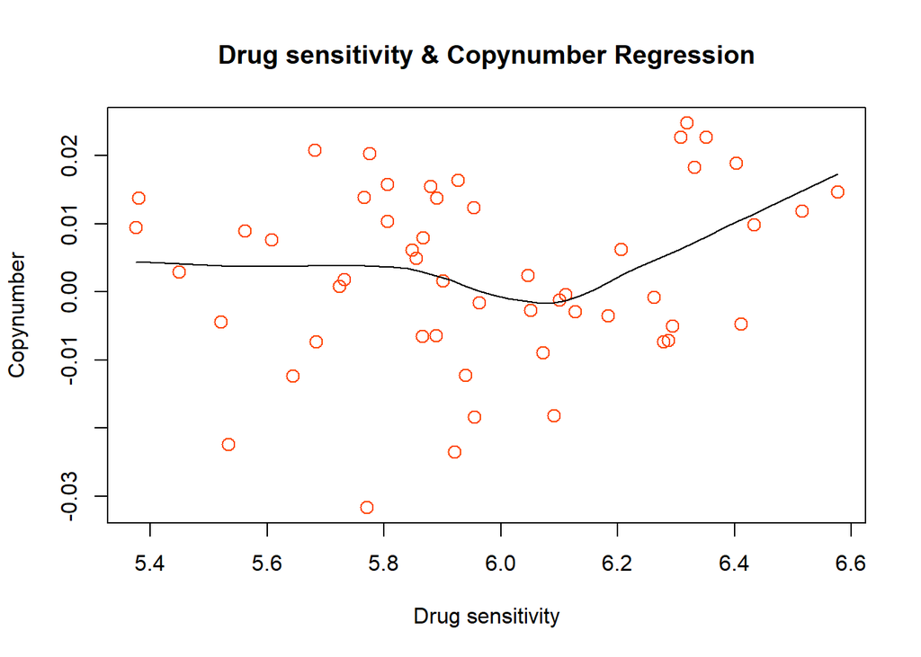

```r
scatter.smooth(lm_tab_all2$vorinostat,
               lm_tab_all2$CN_meancol,
               col = "orangered",
               main = "Drug sensitivity & Copynumber Regression",
               xlab = "Drug sensitivity",
               ylab = "Copynumber",
               cex = 1.3,
               pch = 1)
```

At first look, the points in the plot are so extremely scattered, that a linear relationship seems really unlikely. The second problem that one can observe in this graphic, is that the line describing the behaviour is not straight.

#### (2) Box plot

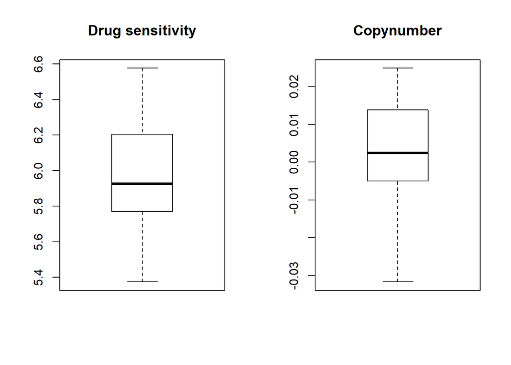

```r
par(mfrow=c(1, 2))
boxplot(lm_tab_all2$vorinostat,
        main="Drug sensitivity")
boxplot(lm_tab_all2$CN_meancol,
        main="Copynumber")
```

No outliers can be observed.

#### (3) Density: Should we expect normality for drug sensitivity?

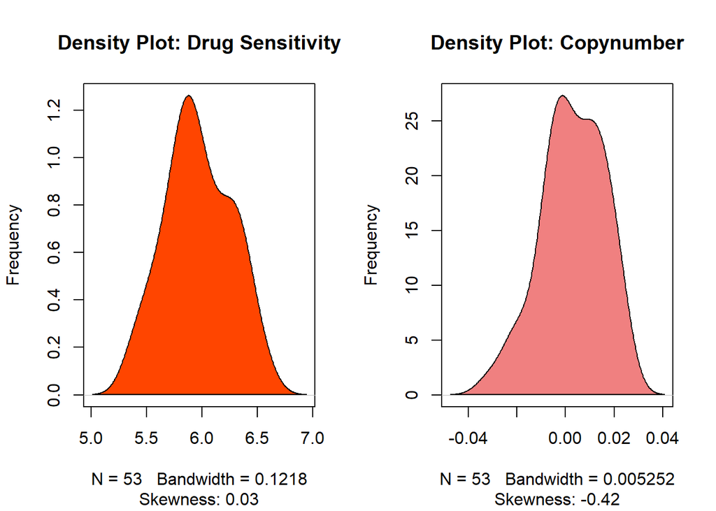

```r
par(mfrow=c(1, 2))

plot(density(lm_tab_all2$vorinostat),
     main="Density Plot: Drug Sensitivity",
     ylab="Frequency",
     sub=paste("Skewness:", round(e1071::skewness(lm_tab_all2$vorinostat), 2))
    )

polygon(density(lm_tab_all2$vorinostat), col="orangered")
plot(density(lm_tab_all2$CN_meancol),
     main="Density Plot: Copynumber",
     ylab="Frequency",
     sub=paste("Skewness:", round(e1071::skewness(lm_tab_all2$CN_meancol), 2))
    )

polygon(density(lm_tab_all2$CN_meancol), col="lightcoral")
```

Skewness of the plot on the left: 0.03 -> Plot is very slightly skewed to the right.

Skewness of the plot on the right: -0.42 -> Plot is skewed to the left.

#### (4) Correlation: what is the level level of linear dependence between the two variables?

```r
cor(lm_tab_all2$vorinostat, lm_tab_all2$CN_meancol)
```

```
## [1] 0.1534729
```

The value here is too low and therefore indicates an extremely weak relationship between both variables.

Although no outliers were observed in the box plot results, all ther results seem to indicate that a linear regression is most likely not the best model to describe our data.

## 5.2 Linear Regression

### Linear Regression

```r
reg_all2 <- lm(vorinostat ~ CN_meancol, data = lm_tab_all2)
```

### Details about the linear regression: what we need draw some conclusions

```r
summary(reg_all2)
```

```
##
## Call:
## lm(formula = vorinostat ~ CN_meancol, data = lm_tab_all2)
##
## Residuals:
##      Min       1Q   Median       3Q      Max
## -0.62533 -0.23078 -0.04434  0.23929  0.56731
##
## Coefficients:
##             Estimate Std. Error t value Pr(>|t|)
## (Intercept)  5.95623    0.04205 141.658   <2e-16 ***
## CN_meancol   3.56035    3.20996   1.109    0.273
## ---
## Signif. codes:  0 '***' 0.001 '**' 0.01 '*' 0.05 '.' 0.1 ' ' 1
##
## Residual standard error: 0.2989 on 51 degrees of freedom
## Multiple R-squared:  0.02355,    Adjusted R-squared:  0.004408
## F-statistic:  1.23 on 1 and 51 DF,  p-value: 0.2726
```

Multiple R-squared:  
0.02355 -> This indicates that only 2.355% percent of the variation in the data (drug sensitivity) can be explained by the relationship between drug sensitivity and copynumber. In other words, there is a 2.355% variance reduction when we take the copynumber into account.

p-value: 0.2726 As the p-value for reg_all2 is significantly larger than 0.05 and R-squared tells us the copynumber only explains 2.355% of the variation in the data, it is safe to assume that there is no linear relationship between drug sensitivity and copynumer, a.k.a copynumber cannot predict drug sensitivity.

#### More information about the fit (linear ecuation: y = y-intercept + slope * x) :

```r
confint(reg_all2)
```

```
##                 2.5 %    97.5 %
## (Intercept)  5.871818  6.040642
## CN_meancol  -2.883917 10.004613
```

We can also visualize the results of the confidence interval

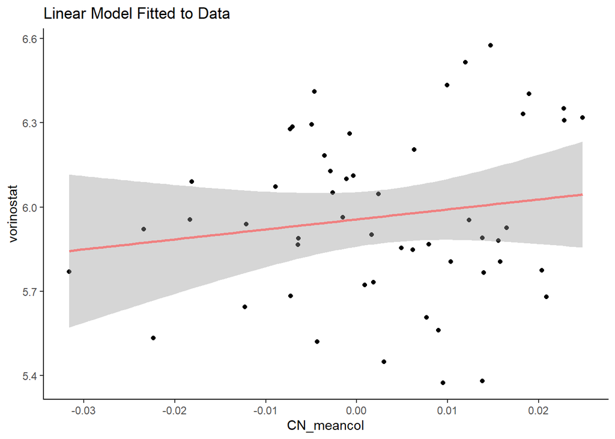

```r
library(ggplot2)

ggplot(data = lm_tab_all2, aes(x = CN_meancol, y = vorinostat)) +
  geom_point() +
  stat_smooth(method = "lm", col = "lightcoral", level = 0.975) +
  theme(panel.background = element_rect(fill = "white"),
        axis.line.x=element_line(),
        axis.line.y=element_line()) +
  ggtitle("Linear Model Fitted to Data")
```

## 5.3 Checking the normalization of residuals

Here we explore two ways to visualize the normalization of residuals.

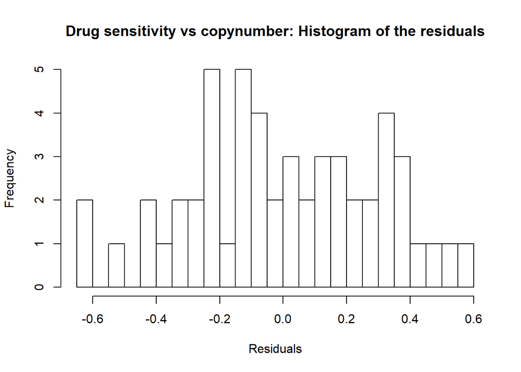

```r
hist(reg_all2$residuals,
     breaks = 20,
     xlab = "Residuals",
     main = "Drug sensitivity vs copynumber: Histogram of the residuals")
```

The data does NOT look normally distributed. This menas that the linear regression model does not explain all trends in the dataset.

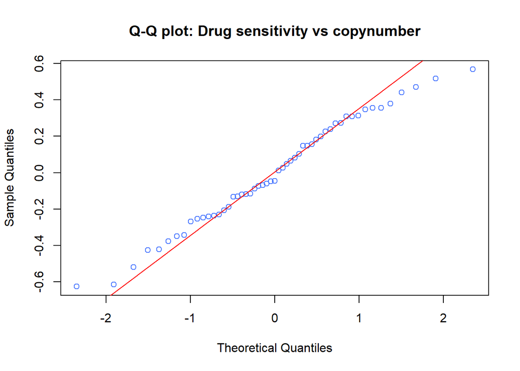

```r
qqnorm(reg_all2$residuals, col = "royalblue1", main = "Q-Q plot: Drug sensitivity vs copynumber")
qqline(reg_all2$residuals, col = "red")
```

Many data points at both extremes do not follow the line that dictates the behaviour in the linear relationship. Therefore, asuming normalization is discarded.

## 5.4 Visualization: Plots that describe the linear regression

#### Residual diagnostics: are the various assumptions that underpin linear regression reasonable for our data?

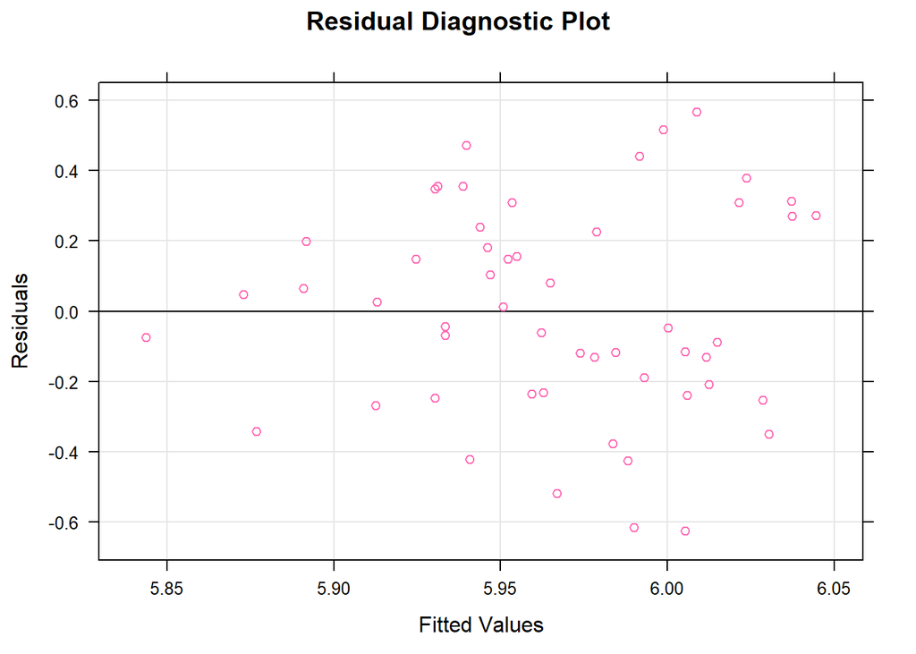

```r
library(lattice)

xyplot(resid(reg_all2) ~ fitted(reg_all2),
       xlab = "Fitted Values",
       ylab = "Residuals",
       main = "Residual Diagnostic Plot",
       col = "hotpink",
       panel = function(x, y, ...)
       {
         panel.grid(h = -1, v = -1)
         panel.abline(h = 0)
         panel.xyplot(x, y, ...)
       }
      )
```

#### Visualization of regression

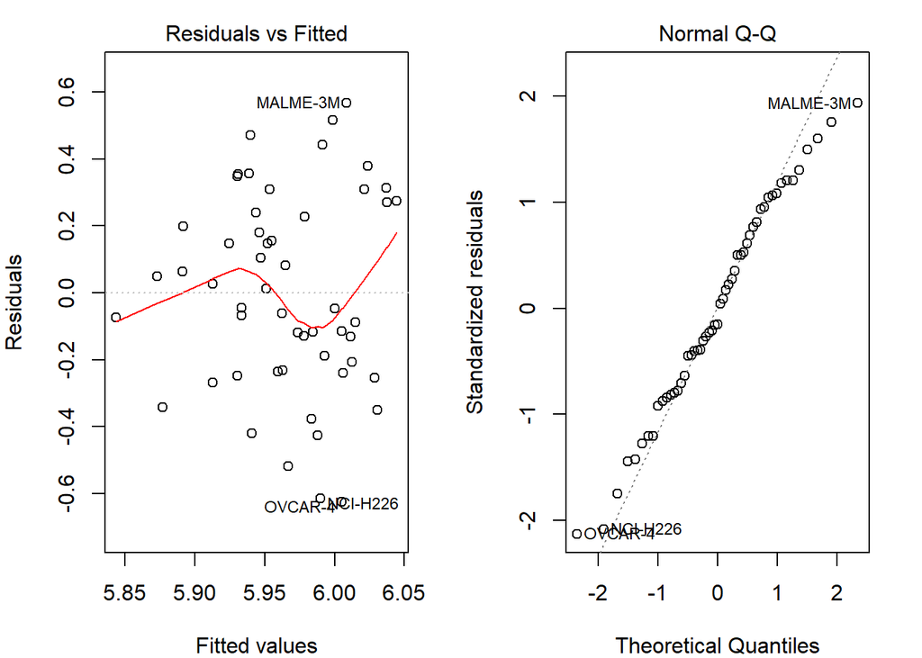

```r
par(mar = c(4, 4, 2, 2), mfrow = c(1, 2))
plot(reg_all2, which = c(1, 2))
```

Looking at the red line of the graph on the left side, we can confirm the results of the summary of the regression. The low R-squared value is better visualized here. If a linear regression was a good model to explain our data, then the red line would be straight and would go right through the middle of the graph.

#### Comparing prediction and real values for drug sensitivity

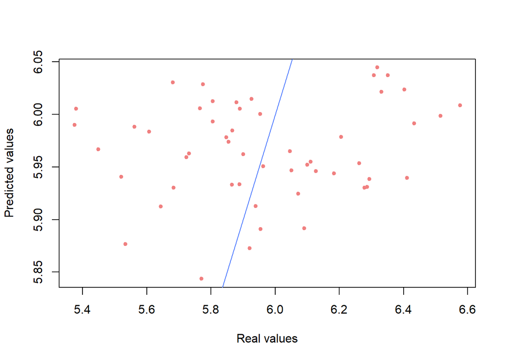

```r
plot(lm_tab_all2$vorinostat,
     reg_all2$fitted.values,
     pch = 20, col = "lightcoral",
     xlab = "Real values",
     ylab = "Predicted values")
abline(0, 1, col = "royalblue1")
```

The data points are very scattered.

# 6. MULTIPLE REGRESSION WITH ALL GENES: Drug sensitivity with doubling time and copynumber

### Data frames

```r
CN_all = as.data.frame(CN_meancol)

DT = as.data.frame(Doubling_Time)

DS = as.data.frame(drug_sensitivity)
```

### Table with drug sensitivity, copynumber and doubling time per cell line

```r
lm_tab_m = transform(merge(CN_all,
                           lm_tab,by=0,all=TRUE),
                          row.names=Row.names,
                          Row.names=NULL
                    )

names(lm_tab_m)[names(lm_tab_m) == "CN_meancol"] <- "Copynumber"
names(lm_tab_m)[names(lm_tab_m) == "vorinostat"] <- "Drug_Sensitivity"

lm_tab_m <- na.omit(lm_tab_m)
```

## 6.1 Plots and visualization: Predicting how fit linear regression will be as a model to describe our data

### Ploting the data: can a linear relationship be observed? Should we have expected a high value for R-squared?

#### Visualization of doubling time vs drug sensitivity

#### Loading packages

```r
library(ggplot2)
library(scatterplot3d)
library(car)
library(scatterD3)
library(rgl)
```

#### (1) Plot

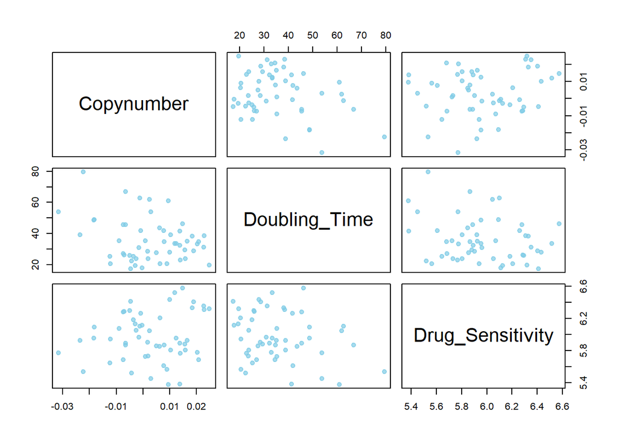

```r
plot(lm_tab_m ,
     pch=20 ,
     cex=1.5 ,
     col=rgb(0.5, 0.8, 0.9, 0.7)
    )
```

There seems to be no linear relationship, because of how spread the points are.

#### (2) Box plot

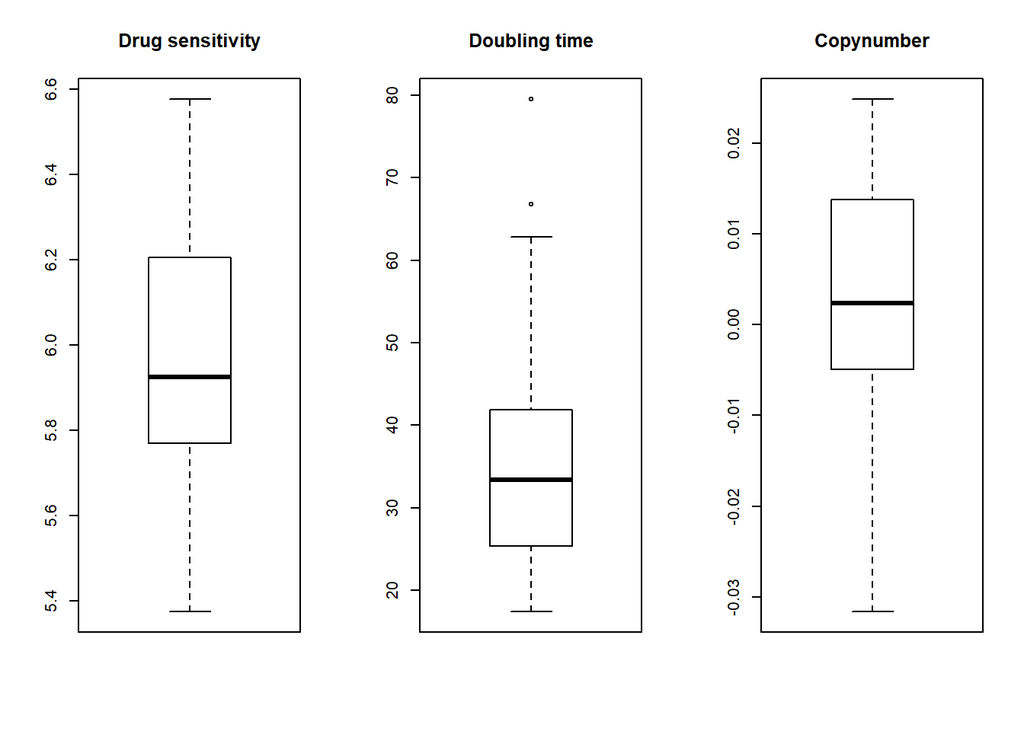

```r
par(mfrow=c(1, 3))
boxplot(lm_tab_m$Drug_Sensitivity,
        main="Drug sensitivity")
boxplot(lm_tab_m$Doubling_Time,
        main="Doubling time")
boxplot(lm_tab_m$Copynumber,
        main="Copynumber")
```

Just as before we see only outliers for doubling time.

#### (3) Density: Should be expect normality for drug sensitivity?

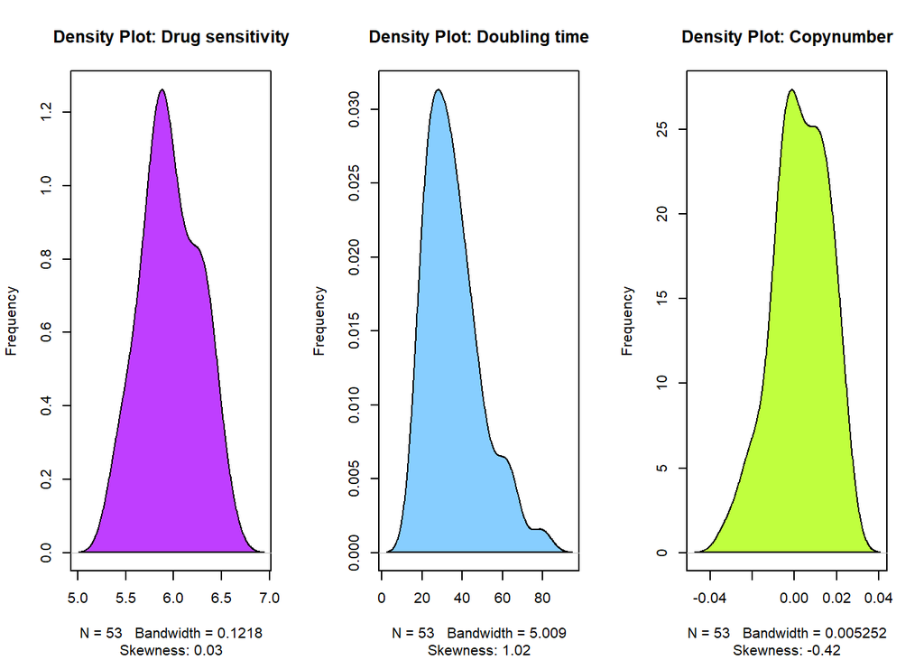

```r
par(mfrow=c(1, 3))

plot(density(lm_tab_m$Drug_Sensitivity),
     main="Density Plot: Drug sensitivity",
     ylab="Frequency",
     sub=paste("Skewness:", round(e1071::skewness(lm_tab_m$Drug_Sensitivity), 2))
     )

polygon(density(lm_tab_m$Drug_Sensitivity), col="darkorchid1")

plot(density(lm_tab_m$Doubling_Time),
     main="Density Plot: Doubling time",
     ylab="Frequency",
     sub=paste("Skewness:", round(e1071::skewness(lm_tab_m$Doubling_Time), 2))
     )

polygon(density(lm_tab_m$Doubling_Time), col="skyblue1")

plot(density(lm_tab_m$Copynumber),
     main="Density Plot: Copynumber",
     ylab="Frequency",
     sub=paste("Skewness:", round(e1071::skewness(lm_tab_m$Copynumber), 2))
     )

polygon(density(lm_tab_m$Copynumber), col="olivedrab1")
```

Skewness of the plot on the left: 0.03 -> Plot is very slightly skewed to the right.

Skewness of the plot on the right:: -0.42 -> Plot is slightly skewed to the left.

### Checking for correlation

```r
cor(lm_tab_m)
```

```
##                  Copynumber Doubling_Time Drug_Sensitivity
## Copynumber        1.0000000    -0.2754990        0.1534729
## Doubling_Time    -0.2754990     1.0000000       -0.2360583
## Drug_Sensitivity  0.1534729    -0.2360583        1.0000000
```

None of the values here indicate a strong linear relationship.

Thanks to the outliers, considerably spread plots and skewed density plots, it is not unreasonable to predict that a multiple regression with these parameters will probably not be the best model to describe the relationships in our data.

## 6.2 Linear Regression

### Linear Regression

```r
reg_m <- lm(Drug_Sensitivity ~ Copynumber + Doubling_Time, data = lm_tab_m)
```

### Details about the linear regression: what we need draw some conclusions

```r
summary(reg_m)
```

```
##
## Call:
## lm(formula = Drug_Sensitivity ~ Copynumber + Doubling_Time, data = lm_tab_m)
##
## Residuals:
##      Min       1Q   Median       3Q      Max
## -0.58469 -0.24027 -0.01499  0.23087  0.63105
##
## Coefficients:
##                Estimate Std. Error t value Pr(>|t|)
## (Intercept)    6.122362   0.120171  50.947   <2e-16 ***
## Copynumber     2.220168   3.301494   0.672    0.504
## Doubling_Time -0.004548   0.003087  -1.473    0.147
## ---
## Signif. codes:  0 '***' 0.001 '**' 0.01 '*' 0.05 '.' 0.1 ' ' 1
##
## Residual standard error: 0.2955 on 50 degrees of freedom
## Multiple R-squared:  0.06419,    Adjusted R-squared:  0.02675
## F-statistic: 1.715 on 2 and 50 DF,  p-value: 0.1904
```

The coefficients show that better results are yielded when using doubling time alone to predict drug sensitivity,than when using both doubling time and copynumber.

### RMSE: A measure of how accurately the model predicts the response

```r
n = nrow(lm_tab_m)
rmse = sqrt(1/n * sum(reg_m$residuals^2))
rmse
```

```
## [1] 0.2869944
```

#### More information about the fit (linear ecuation: y = y-intercept + slope * x) :

```r
confint(reg_m)
```

```
##                     2.5 %      97.5 %
## (Intercept)    5.88099195 6.363731379
## Copynumber    -4.41107854 8.851414978
## Doubling_Time -0.01074799 0.001651769
```

## 6.3 Checking the normalization of residuals

Here we explore two ways to visualize the normalization of residuals.

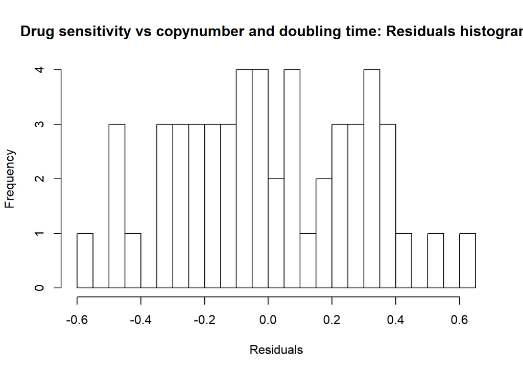

```r
hist(reg_m$residuals,
     breaks = 20,
     xlab = "Residuals",
     main = "Drug sensitivity vs copynumber and doubling time: Residuals histogram")
```

The data does NOT look normally distributed.

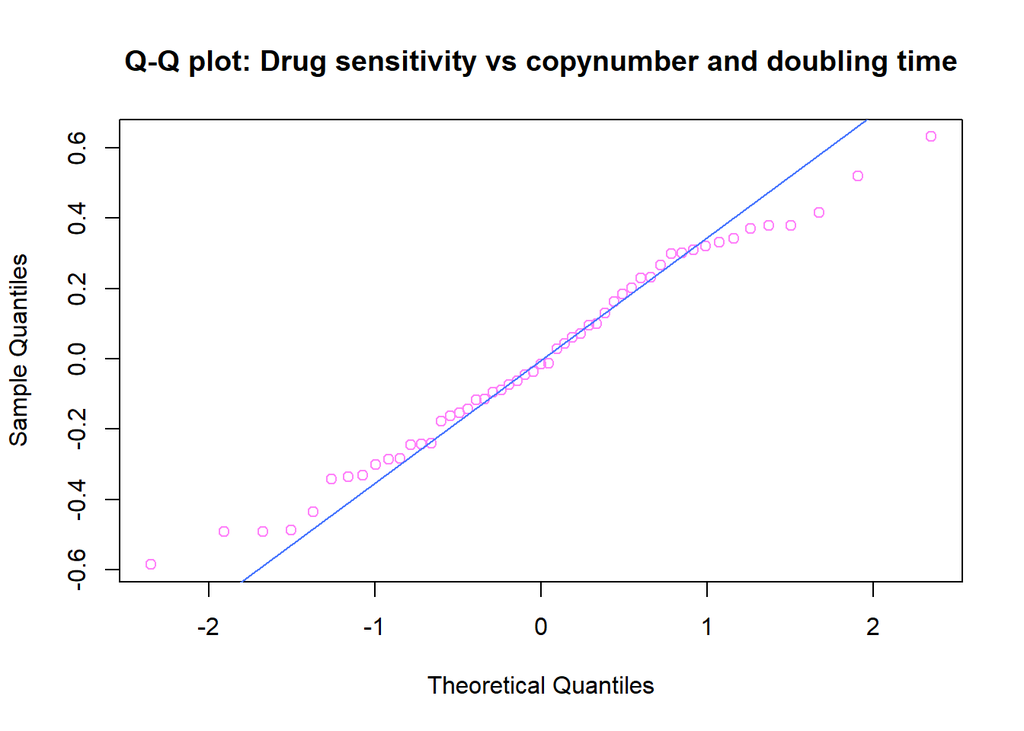

```r
qqnorm(reg_m$residuals, col = "orchid1", main = "Q-Q plot: Drug sensitivity vs copynumber and doubling time")
qqline(reg_m$residuals, col = "royalblue1")
```